# ゲームハード週販レポート (2026.01.11)

国内ゲームハード週販レポート (2026-01-11)

- ハードウェアの販売データはファミ通の調査結果を基にしています。
- 2026/1/11は2週合算だったため､データは処理上の都合､週次値に変換するため1/4と1/11に等分しています｡
- 過去の週販レポート

## 直近4週間のハード売り上げ／累計推移

| 集計日 | ハード | 販売台数 | 累計台数 |
| --- | --- | --- | --- |
| 2025-12-21 | Nintendo Switch2 | 221,033 | 3,583,810 |
|  | Nintendo Switch | 38,184 | 36,383,386 |
|  | PlayStation5 | 19,307 | 7,278,978 |
|  | Xbox Series X\|S | 184 | 689,257 |
|  | PlayStation4 | 12 | 9,491,032 |
| 2025-12-28 | Nintendo Switch2 | 200,257 | 3,784,067 |
|  | Nintendo Switch | 32,775 | 36,416,161 |
|  | PlayStation5 | 19,232 | 7,298,210 |
|  | Xbox Series X\|S | 297 | 689,554 |
|  | PlayStation4 | 15 | 9,491,047 |
| 2026-01-04 | Nintendo Switch2 | 156,919 | 3,940,986 |
|  | PlayStation5 | 23,376 | 7,321,586 |
|  | Nintendo Switch | 23,180 | 36,439,341 |
|  | Xbox Series X\|S | 140 | 689,694 |
|  | PlayStation4 | 12 | 9,491,059 |
| 2026-01-11 | Nintendo Switch2 | 156,919 | 4,097,905 |
|  | PlayStation5 | 23,377 | 7,344,963 |
|  | Nintendo Switch | 23,180 | 36,462,521 |
|  | Xbox Series X\|S | 141 | 689,835 |
|  | PlayStation4 | 13 | 9,491,072 |

年始もSwitch2の勢いは止まらず､二週間で31万台を販売し､累計が400万台を突破しました｡

年始のPS5は絶好調でした｡2週間で4万6千台を販売し､730万台を超えました｡ 第4四半期に強いPlayStationは健在です｡

SwitchはPS5を僅かに下回りました｡ 一部で品切れも伝えられており､世代交代が加速しています｡

## 週販推移

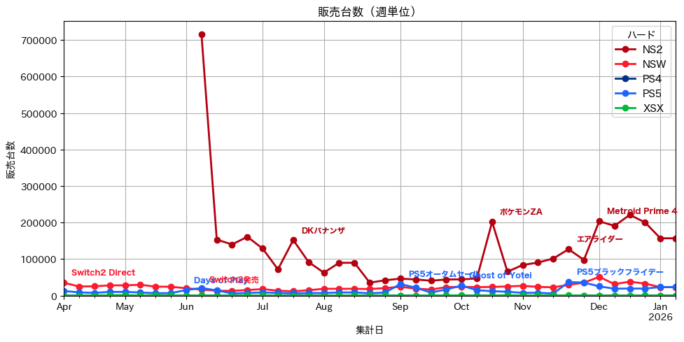

### 週販推移(拡大）

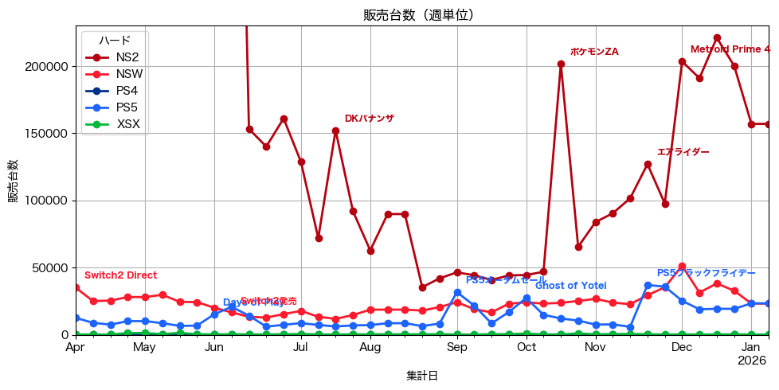

12月ほどの出荷数はありませんが､Switch2は年始も大量に販売されました｡ 一方､Switchは落ち着いていくことでしょう｡週あたり2万を切るのが通常になると思います｡

PS5はクリスマスシーズンよりも好調です｡ 例年､1月, 2月, 3月が好調なPlayStation.この3ヶ月間で2026年の趨勢が決まります｡

## 月間販売推移

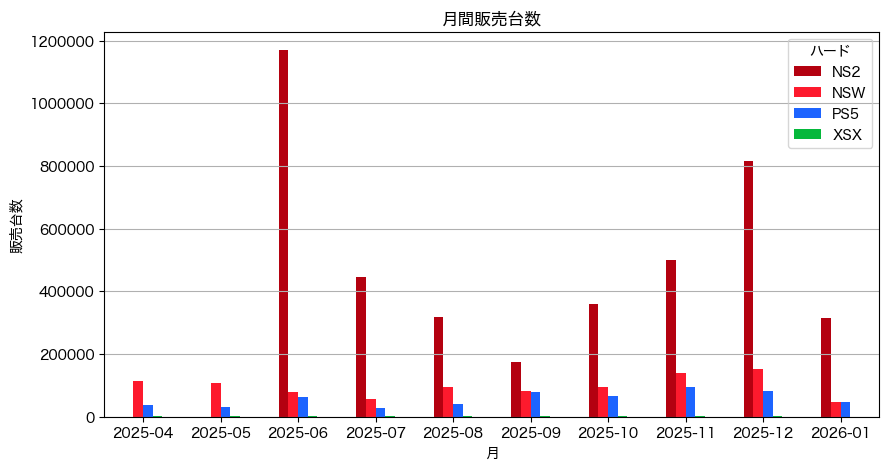

### Nintendo Switchの月間販売台数： 前々年､前年との比較

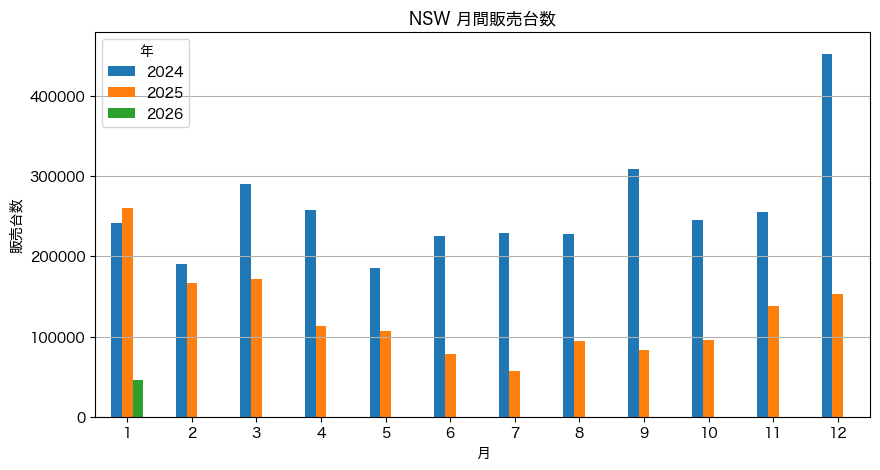

| year month | 2025 | 2026 | YoY |
| --- | --- | --- | --- |
| 1 | 260,447 | 46,360 | 17.8% |
| 2 | 167,188 | 0 | 0.0% |
| 3 | 171,921 | 0 | 0.0% |
| 4 | 113,513 | 0 | 0.0% |
| 5 | 106,506 | 0 | 0.0% |
| 6 | 78,097 | 0 | 0.0% |
| 7 | 57,532 | 0 | 0.0% |
| 8 | 94,517 | 0 | 0.0% |
| 9 | 82,946 | 0 | 0.0% |
| 10 | 96,080 | 0 | 0.0% |
| 11 | 138,018 | 0 | 0.0% |
| 12 | 153,619 | 0 | 0.0% |

既に1月は2週間分合算であることを考慮すると､ 2026年1月の前年比は40%に届かない､急激な落ち込みの可能性が高いです｡

### PlayStation 5の月間販売台数： 前々年､前年との比較

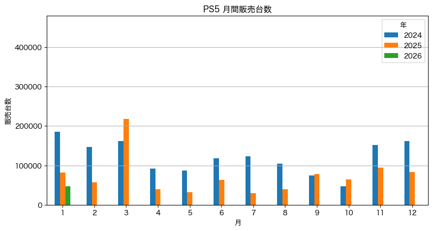

| year month | 2025 | 2026 | YoY |
| --- | --- | --- | --- |
| 1 | 81,587 | 46,753 | 57.3% |
| 2 | 56,886 | 0 | 0.0% |
| 3 | 218,300 | 0 | 0.0% |
| 4 | 38,983 | 0 | 0.0% |
| 5 | 32,001 | 0 | 0.0% |
| 6 | 63,516 | 0 | 0.0% |
| 7 | 28,959 | 0 | 0.0% |
| 8 | 39,004 | 0 | 0.0% |
| 9 | 78,693 | 0 | 0.0% |
| 10 | 64,732 | 0 | 0.0% |
| 11 | 93,852 | 0 | 0.0% |
| 12 | 82,691 | 0 | 0.0% |

PS5の2026年1月は好調です｡値下げ効果が出てきたのか､昨年の1月を超える可能性があります｡

## 累計販売推移

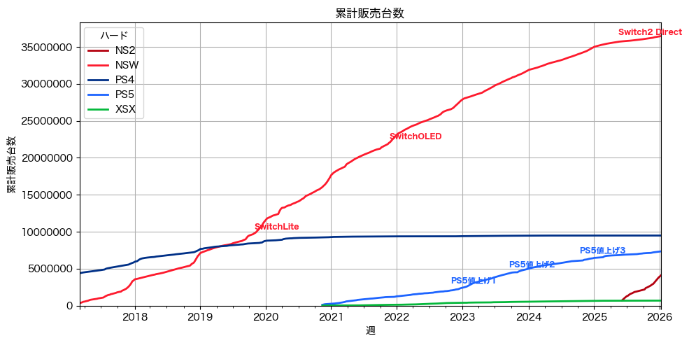

Switch2の累計は409万台に到達しました｡ 一方､PS5の累計が730万台に到達しました｡

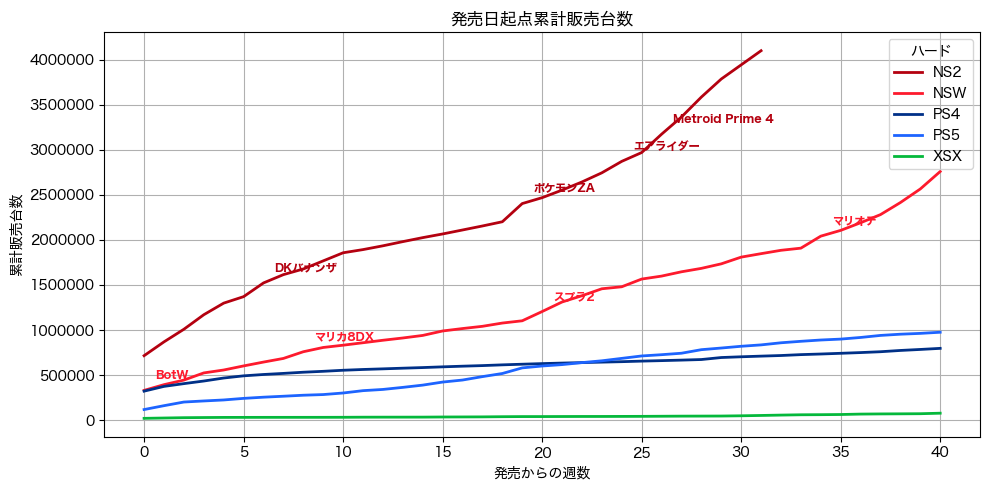

### PS5値下げ効果をPS4と比較で可視化

Switch2対抗として語られることもあるPS5DE日本語版の値下げですが､その面での効果は特にありませんでした｡ しかし､PS4との推移比較では重要な効果を発揮していることが分かります｡

以下は､PS4とPS5のそれぞれの発売からの累計台数の推移をプロットしたものです｡横軸は週(Week)です｡

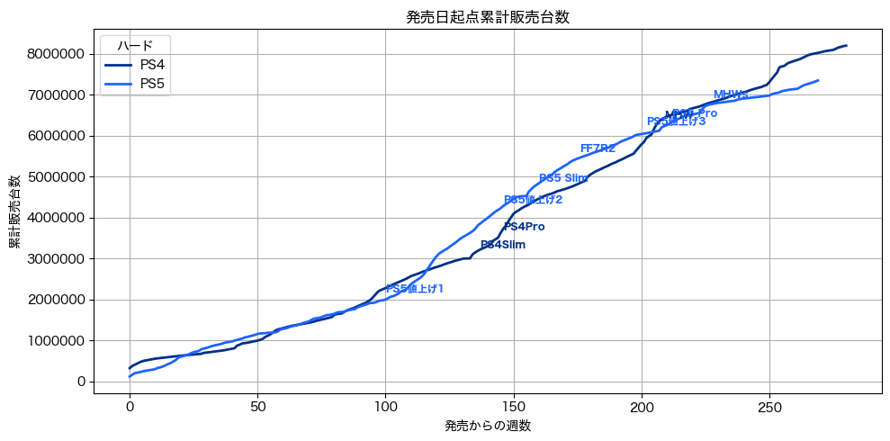

100週まではPS4,PS5は同等ですが､120週目あたりからPS5が加速しPS4を上回ります｡ しかし､200週を超えた辺りで逆転します｡MHWs効果で225週目でPS5はPS4に追いつきそうになりますが､ その後のPS5はPS4に遅れを取り､差はどんどん広がっていきます｡

以下は､PS4,PS5の同時期の累計差のグラフです｡プラスの値ならPS5が(PS4比で)好調､マイナス値ならPS5不調(PS4比で)を示します｡

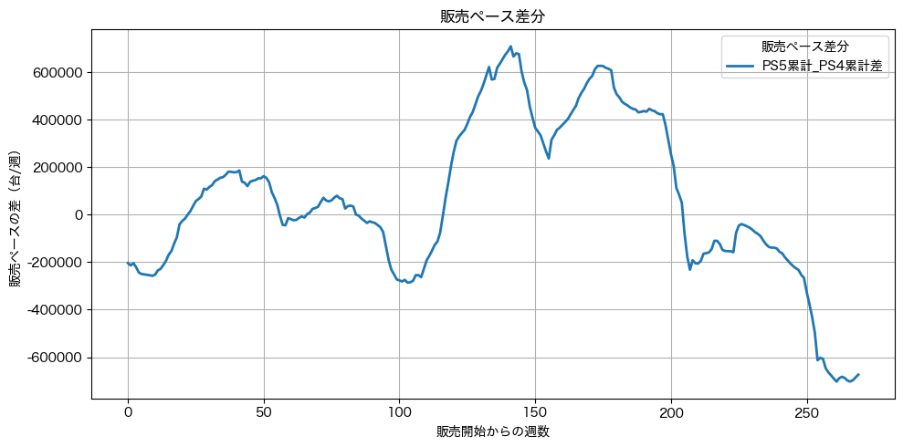

225週目､MHWs効果で一旦0に近づきますが､その後は急降下しています｡ これはMHWs以降のPS5がPS4に比べて極めて不調であったことを示します｡ (大作ソフト発売後に絶不調になるのはソニーにとっても予想困難だったでしょう)

この急降下を止めたのが **PS5DE日本語版の値下げ** です｡

PS5とPS4の差は値下げ版発売週直前の2025/11/16に最低値の-703,092台を記録した後､ 値下げとブラックフライデー効果により､-682,674まで持ち直しました｡ 2026/1/11集計でも -673,797 で､値下げ前の最悪値から持ち直しています｡

つまり､PS5DE日本語版の値下げにより､**同時期のPS4と同程度のペース** になりつつあります｡

|  | PS5累計_PS4累計差 | PS4集計週 | PS5集計週 |
| --- | --- | --- | --- |
| 260 | -690,575 | 2019-02-17 | 2025-11-09 |
| 261 | -703,092 | 2019-02-24 | 2025-11-16 |
| 262 | -688,511 | 2019-03-03 | 2025-11-23 |
| 263 | -682,674 | 2019-03-10 | 2025-11-30 |
| 264 | -687,382 | 2019-03-17 | 2025-12-07 |
| 265 | -698,216 | 2019-03-24 | 2025-12-14 |
| 266 | -702,772 | 2019-03-31 | 2025-12-21 |
| 267 | -697,394 | 2019-04-07 | 2025-12-28 |
| 268 | -685,811 | 2019-04-14 | 2026-01-04 |
| 269 | -673,797 | 2019-04-21 | 2026-01-11 |

これが一時的な効果なのか､2026年を通じて効果があるのかに注目です｡

## Switch2初動状況

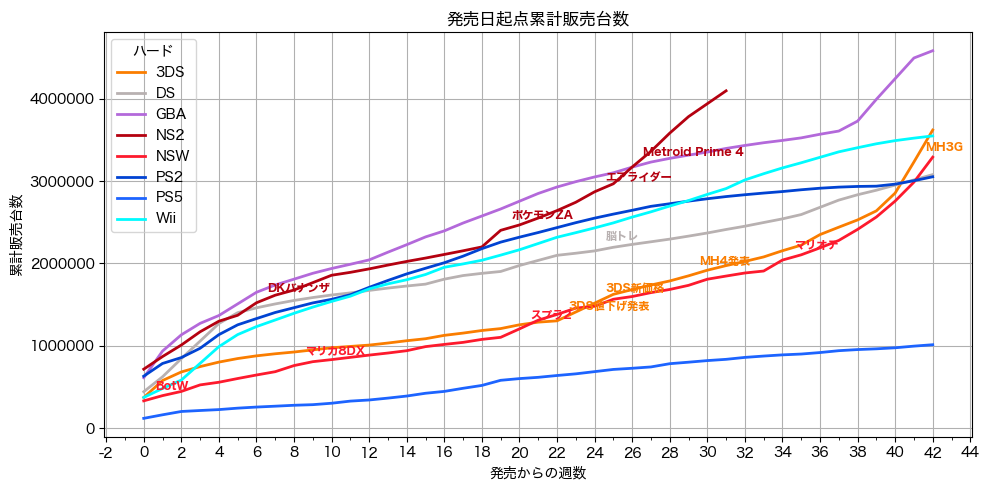

| ハード | 週数 | 販売数 |
| --- | --- | --- |
| NS2 | 31 | 4,097,905 |
| GBA | 31 | 3,397,822 |
| Wii | 31 | 2,909,931 |
| PS2 | 31 | 2,812,871 |
| DS | 31 | 2,412,921 |
| 3DS | 31 | 1,973,953 |
| NSW | 31 | 1,847,008 |
| PS5 | 31 | 835,145 |

Switch2は32週目で400万台を突破し､歴代初動1位の座をキープしています｡ GBAよりも7週間早い達成です｡

## 年単位の状況

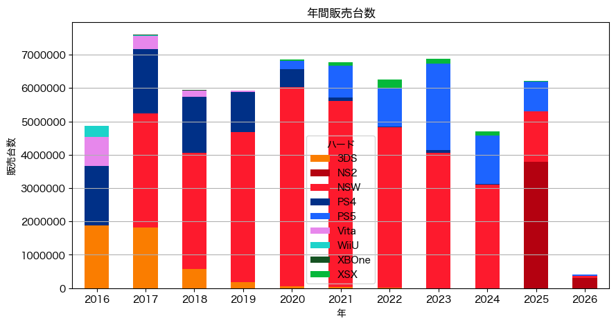

| hw year | 3DS | NS2 | NSW | PS4 | PS5 | Vita | WiiU | XBOne | XSX | 合計 |
| --- | --- | --- | --- | --- | --- | --- | --- | --- | --- | --- |
| 2016 | 1,874,457 | 0 | 0 | 1,790,883 | 0 | 865,002 | 336,151 | 8,897 | 0 | 4,875,390 |
| 2017 | 1,827,131 | 0 | 3,407,158 | 1,935,247 | 0 | 396,207 | 21,817 | 14,664 | 0 | 7,602,224 |
| 2018 | 566,420 | 0 | 3,482,388 | 1,695,227 | 0 | 181,728 | 0 | 15,339 | 0 | 5,941,102 |
| 2019 | 191,173 | 0 | 4,493,903 | 1,196,153 | 0 | 37,668 | 0 | 8,315 | 0 | 5,927,212 |
| 2020 | 62,761 | 0 | 5,956,943 | 542,647 | 255,150 | 0 | 0 | 3,585 | 31,424 | 6,852,510 |
| 2021 | 28,540 | 0 | 5,579,127 | 104,054 | 968,185 | 0 | 0 | 0 | 97,234 | 6,777,140 |
| 2022 | 10,664 | 0 | 4,804,546 | 22,823 | 1,154,054 | 0 | 0 | 0 | 269,737 | 6,261,824 |
| 2023 | 3,033 | 0 | 4,062,609 | 73,292 | 2,587,468 | 0 | 0 | 0 | 141,712 | 6,868,114 |
| 2024 | 162 | 0 | 3,109,103 | 13,728 | 1,454,149 | 0 | 0 | 0 | 118,221 | 4,695,363 |
| 2025 | 0 | 3,784,067 | 1,520,384 | 1,087 | 879,204 | 0 | 0 | 0 | 31,226 | 6,215,968 |
| 2026 | 0 | 313,838 | 46,360 | 25 | 46,753 | 0 | 0 | 0 | 281 | 407,257 |

### 年単位のメーカーシェア

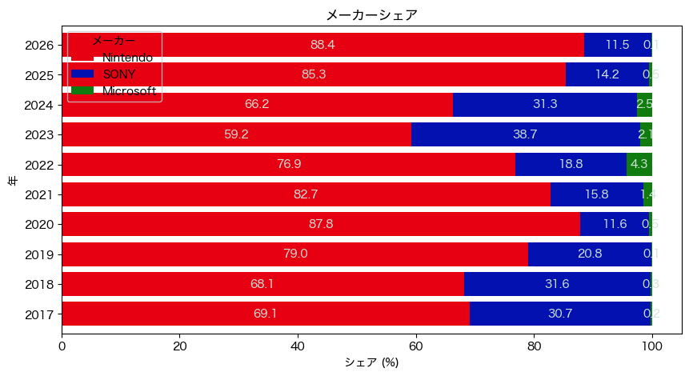

2026年､最初の集計では任天堂のシェアは88.4%に達しました｡ しかし第4四半期に強いPSが盛り返していくでしょう｡たぶん｡